# che

# Working example of using Convex Hull Ensembles with the `che` package

## Matt Hill 2019

```r
library(che)
library (raster)
```

```r
library (maptools)
```

```
#> Checking rgeos availability: TRUE
```

```r
library (rgeos)
```

```
#> rgeos version: 0.5-2, (SVN revision 621)
#>  GEOS runtime version: 3.8.0-CAPI-1.13.1
#>  Linking to sp version: 1.4-1
#>  Polygon checking: TRUE
```

```r
# simple world outline from maptools package
data("wrld_simpl")
```

## this data is the in the `che` package - will implement neater soon….

```r
load("../data/insect_dist.Rdata")
```

## Bioclim data

```r
bioclimall <- raster::getData('worldclim', var='bio', res=2.5)
```

# Background creation

This is an important part of a presence-background type modelling. While the che is presence-only, we use GAMs to rank variable pairs based on relative performance, so the backround is used. In this example, the native range for the species is South Africa

```r
e <- extent (10, 40, -35, -15)
SAfrica <- crop (bioclimall, e)
#convert to a stack
SAfrica <- stack(unstack(SAfrica))
```

## Species data

### Halotydeus destructor

This mite is native to South Africa

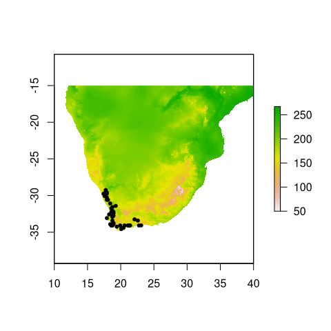

```r
dist <- insect_dist[insect_dist$Species =="h_destructor" & insect_dist$Range == "Native",]

sp_df <- cbind(as.data.frame(dist[,c("Longitude", "Latitude")]),raster::extract(SAfrica, as.data.frame(dist[,c("Longitude", "Latitude")])))
plot (SAfrica[[1]])
points(as.data.frame(dist[,c("Longitude", "Latitude")]), pch=20)
```

## Biomes

The biomes are available as a shapefile from WWF

```r
if (!file.exists("official/wwf_terr_ecos.shp")){
  temp <- tempfile()
  download.file("https://c402277.ssl.cf1.rackcdn.com/publications/15/files/original/official_teow.zip",temp)
  unzip(temp)
  unlink(temp)
}
terres <- readShapePoly("official/wwf_terr_ecos.shp")
```

## Create a raster using biomes and native range points

Using the `che::background_builder` function to set up sampling environment

```r
clim <- cbind(as.data.frame(dist[,c("Longitude", "Latitude")]),raster::extract(SAfrica, as.data.frame(dist[,c("Longitude", "Latitude")])))

nat_ras <- background_builder(distrib=clim,
                              terres=terres,
                              wrld_simpl= wrld_simpl,
                              ref_rast = bioclimall[[1]])

```

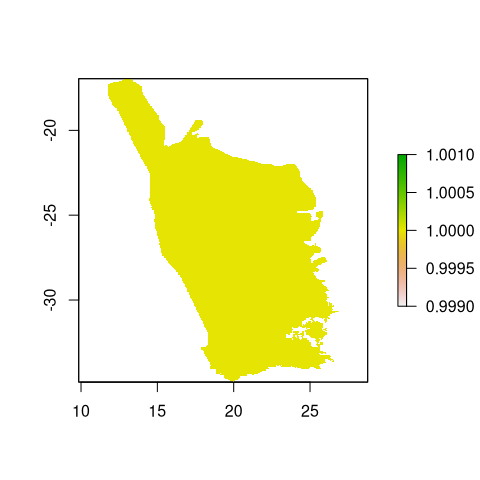

```r
plot (nat_ras)
```

Using the `che::prepare_data` function to prepare the data for the modelling process

```r
model.data <- prepare_data(rasters=bioclimall, mask_raster=nat_ras, predict.to=SAfrica,
             spp.dist=clim[,1:2], w.val=1.e-6, bg.sample = 50000)
```

## Parallel processing of GAMs

```r
model.out <- che_model(spp = "h_destuctor", parallel = TRUE, model.data=model.data)
```

## Reconcile outputs

```r
q_CHE <- che_out(model.out, 0.25)
```

The historgram shows the distribution of relative predictor pair performance, the redlie indicating where the bottom 25% would be excluded from.

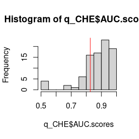

```r
hist(q_CHE$AUC.scores)
abline(v=q_CHE$AUC.thresh, col="red")
```

The resulting map can be plotted using your plotting package of choice, `tmap` is quite useful.

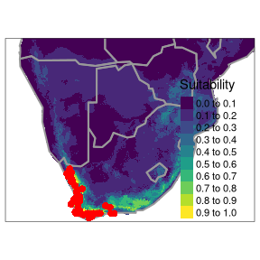

```r
library(tmap)
library (classInt)
library (viridis)
c_dist <- dist[,2:3]
coordinates(c_dist) <- ~Longitude+Latitude

tm_shape(q_CHE$predicted)+
  tm_raster(palette=viridis(10), n=10,
            style="pretty", title="Suitability")+
  tm_shape(wrld_simpl)+
  tm_borders(col="grey60", lwd=2)+
  tm_shape(c_dist)+
  tm_dots(size=0.3, col="red")+
  tm_layout(legend.position=c("right", "BOTTOM"))
```

Overall its done a reasonable job. There is now an opportunity here to test the model predictions using presence-only indices like the Boyce score etc.